## Replication Test

```r
knitr::opts_chunk$set(echo = TRUE, include = TRUE,
                      message = FALSE, warning = FALSE, size = "small")
```

```r
set.seed(890343)
library(rio)
library(dplyr)
library(visualizemi)
library(papaja)
library(tidyr)
library(dmacs)
library(ggplot2)
library(scales)
library(introdataviz)
library(lavaan)
```

## Data

```r
# our data
load("manu_data/RS14.Rdata")

DF <- DF

# take only interesting columns and give a label
DF <- DF %>%
  # make it comparable by only testing students
  filter(DF$sample == "Student") %>%
  mutate(group = "Schulenberg") %>%
  dplyr::select(RS1:RS14, group)

# Chen et al.
DF.pone <- import("manu_data/data1-RS14.dta")
# take only interesting columns and give a label
DF.pone <- DF.pone %>%
  dplyr::select(starts_with("rs")) %>%
  mutate(group = "Chen")
# match column style
colnames(DF.pone)[1:14] <- toupper(colnames(DF.pone)[1:14])

# create one dataset
DF.combo <- bind_rows(DF, DF.pone)

DF.combo %>%
  group_by(group) %>%
  summarize(sample = n())
```

```
## # A tibble: 2 × 2
##   group       sample
##   <chr>        <int>
## 1 Chen          1010
## 2 Schulenberg   1765
```

## MGCFA

```r
# build the one-factor model
model.rs <- "RS =~ RS1+RS2+RS3+RS4+RS5+RS6+RS7+RS8+RS9+RS10+RS11+RS12+RS13+RS14"

# run the multi-group CFA
results.rs <- mgcfa(
  model = model.rs,
  data = DF.combo,
  group = "group",
  group.equal = c("loadings", "intercepts", "residuals")
  )

# examine the results
results.rs$model_fit %>%
        dplyr::select(model, AIC, BIC, cfi, tli, rmsea, srmr)
```

```
## # A tibble: 7 × 7
##   model                 AIC     BIC   cfi   tli  rmsea   srmr
##   <chr>               <dbl>   <dbl> <dbl> <dbl>  <dbl>  <dbl>
## 1 Overall           113442. 113608. 0.939 0.928 0.0890 0.0344
## 2 Group Schulenberg  69101.  69254. 0.928 0.915 0.108  0.0353
## 3 Group Chen         42603.  42741. 0.929 0.916 0.0766 0.0399
## 4 Configural        111760. 112258. 0.929 0.916 0.0975 0.0347
## 5 loadings          111789. 112210. 0.927 0.921 0.0946 0.0427
## 6 intercepts        112785. 113129. 0.892 0.891 0.111  0.0599
## 7 residuals         113318. 113579. 0.873 0.880 0.116  0.0661
```

Overall, the one-factor model fits the data well. Each group also shows adequate model fit. If we use $\Delta$CFI <= .01, we find that the loadings would be considered invariant across the English and Chinese samples. The intercepts were not invariant.

## Partial Invariance

```r
partial.rs <-
  partial_mi(
    saved_model = results.rs$invariance_models$model.intercepts,
    data = DF.combo,
    model = model.rs,
    group = "group",
    # be sure to do only up to the step you are interested in
    group.equal = c("loadings", "intercepts"),
    partial_step = "intercepts")

partial.rs$fit_table %>%
  dplyr::select(free.parameter, cfi) %>%
  arrange(-cfi)
```

```
## # A tibble: 15 × 2
##    free.parameter cfi
##    <chr>          <lvn.vctr>
##  1 "RS2 ~1 "      0.8970997
##  2 "RS11 ~1 "     0.8963948
##  3 "RS4 ~1 "      0.8961938
##  4 "RS12 ~1 "     0.8960095
##  5 "RS14 ~1 "     0.8954496
##  6 "RS1 ~1 "      0.8954215
##  7 "RS10 ~1 "     0.8953395
##  8 "RS3 ~1 "      0.8948455
##  9 "RS5 ~1 "      0.8945236
## 10 "RS7 ~1 "      0.8941450
## 11 "RS8 ~1 "      0.8920022
## 12 "RS13 ~1 "     0.8919491
## 13 "RS9 ~1 "      0.8919293
## 14 "RS ~1 "       0.8917757
## 15 "RS6 ~1 "      0.8917604
```

Examining partial invariance reveals several potential candidates for partial invariance. In this next section, we relaxed group constraints until we achieved partial invariance (i.e., $\Delta$CFI <= .01). We will need to find our CFI as at least 0.92. More than half the items are necessary to achieve “partial” invariance (which really implies no invariance is likely possible).

```r
# run the partially invariant model with group.partial
partial.rs.1 <- mgcfa(model = model.rs,
                  data = DF.combo,
                  group = "group",
                  group.equal = c("loadings", "intercepts"),
                  group.partial = c("RS2 ~1", "RS11 ~1",
                                    "RS4 ~1", "RS12 ~1",
                                    "RS14 ~1", "RS1 ~1",
                                    "RS10 ~1", "RS3 ~ 1"),
                  meanstructure = TRUE)

# examine the fit indices
partial.rs.1$model_fit %>%
  filter(model == "intercepts") %>%
  dplyr::select(AIC, BIC, cfi, tli, rmsea, srmr)
```

```
## # A tibble: 1 × 6
##       AIC     BIC   cfi   tli  rmsea   srmr
##     <dbl>   <dbl> <dbl> <dbl>  <dbl>  <dbl>
## 1 111935. 112326. 0.922 0.917 0.0966 0.0462
```

```r
# examine the intercepts
partial.rs.1$model_coef %>%
  filter(model == "intercepts") %>%
  dplyr::select(term, group, estimate) %>%
  pivot_wider(id_cols = c("term"),
              names_from = "group",
              values_from = "estimate") %>%
  dplyr::rename(English = `1`,
                Chinese = `2`) %>%
  filter(term %in% c("RS1 ~1 ", "RS12 ~1 ",
                     "RS7 ~1 ", "RS4 ~1 ",
                     "RS5 ~1 ", "RS3 ~1 "))
```

```
## # A tibble: 6 × 3
##   term       English Chinese
##   <chr>        <dbl>   <dbl>
## 1 "RS1 ~1 "     5.24    4.78
## 2 "RS3 ~1 "     5.14    5.46
## 3 "RS4 ~1 "     5.29    5.71
## 4 "RS5 ~1 "     5.13    5.13
## 5 "RS7 ~1 "     5.26    5.26
## 6 "RS12 ~1 "    5.57    5.16
```

```r
# effect size model
round(lavaan_dmacs(partial.rs.1$invariance_models$model.intercepts, "Chen")$DMACS, 2)
```

```
##  RS1  RS2  RS3  RS4  RS5  RS6  RS7  RS8  RS9 RS10 RS11 RS12 RS13 RS14
## 0.32 0.29 0.23 0.30 0.00 0.00 0.00 0.00 0.00 0.29 0.27 0.29 0.00 0.26
```

## Visualize Invariance

```
## Plot for RS2
```

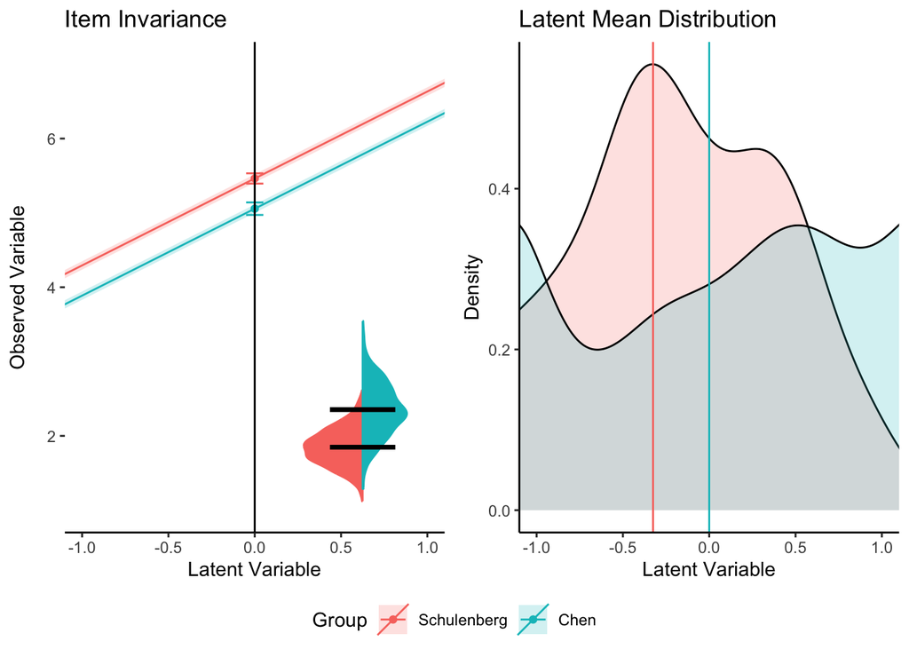

```
## -------
## Plot for RS11
```

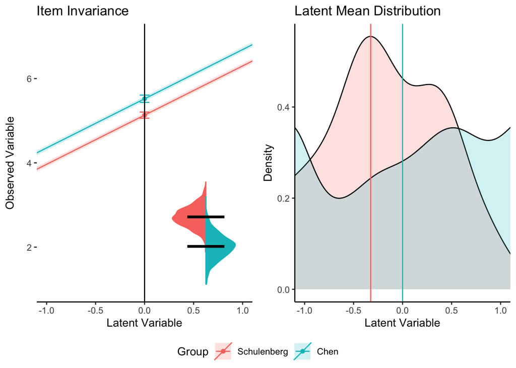

```
## -------
## Plot for RS4
```

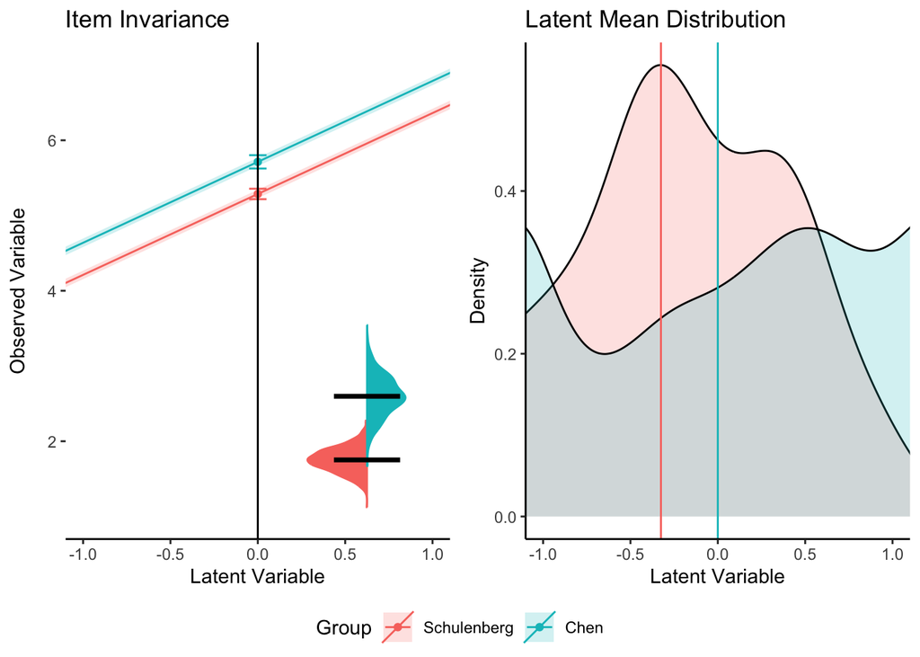

```
## -------
## Plot for RS12
```

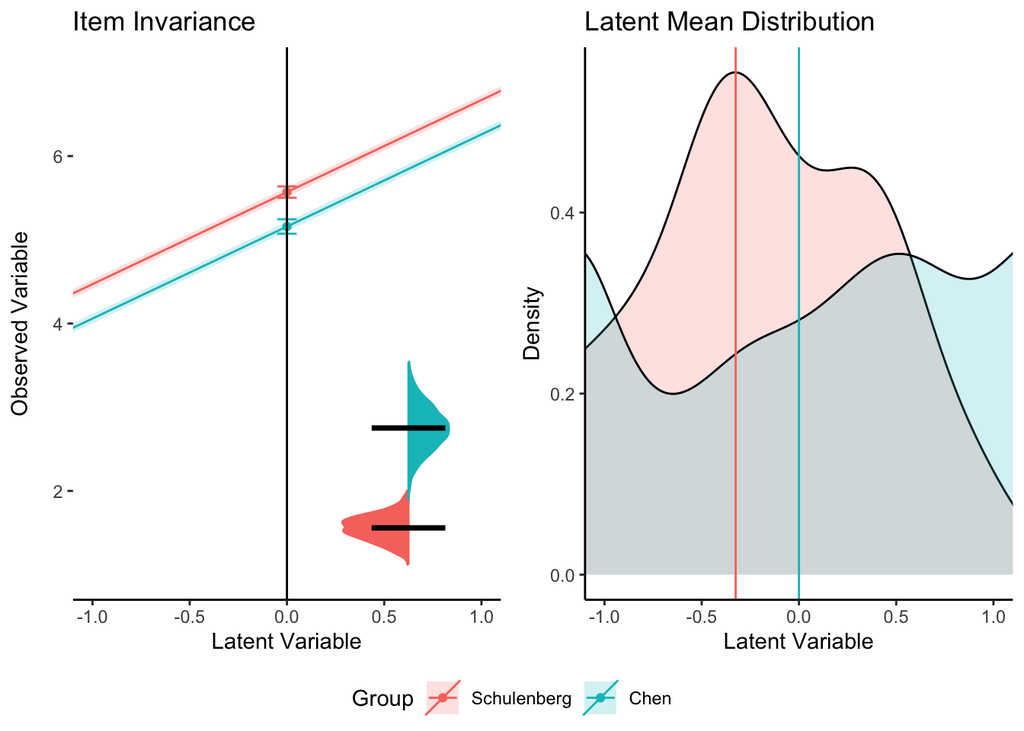

```
## -------
## Plot for RS14
```

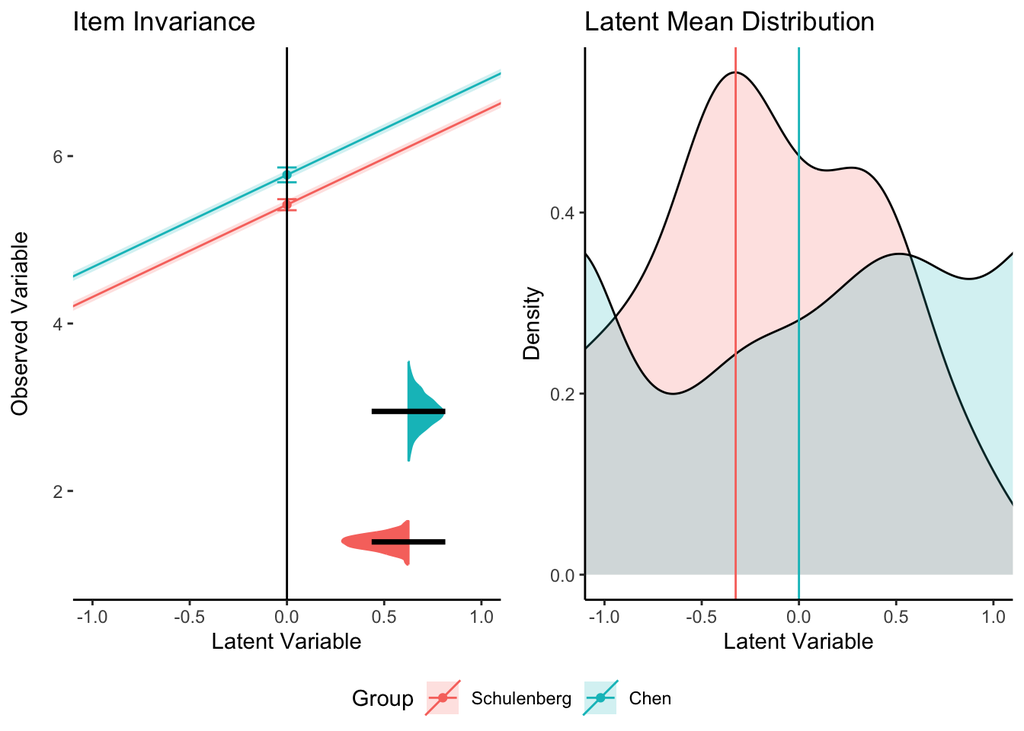

```
## -------
## Plot for RS1
```

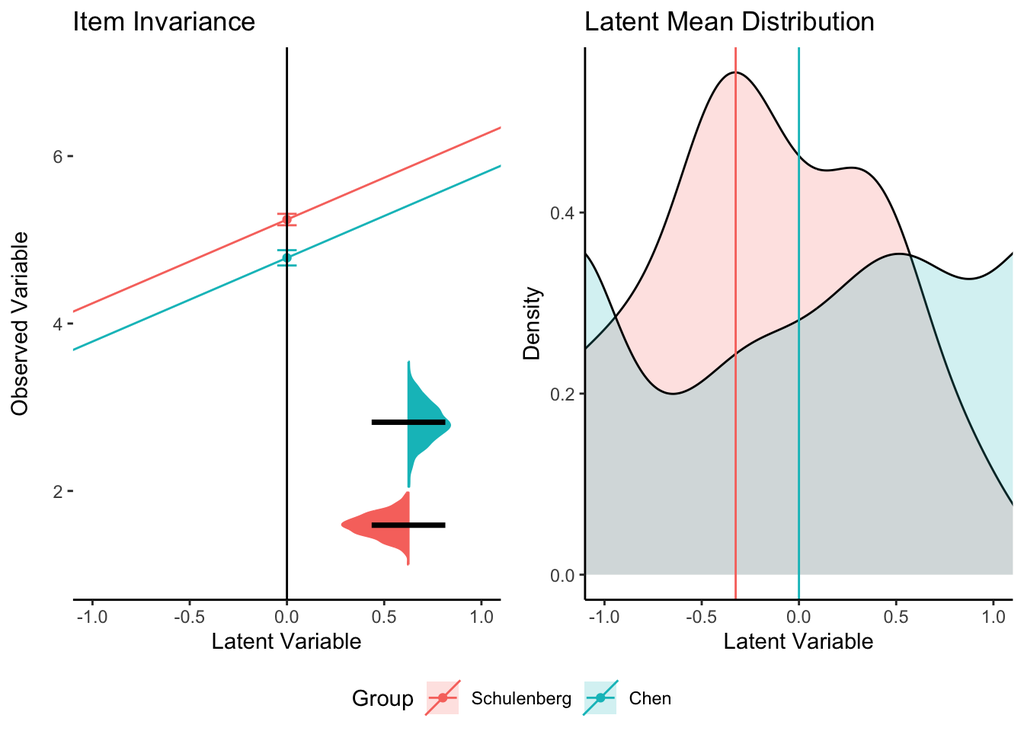

```
## -------
## Plot for RS10
```

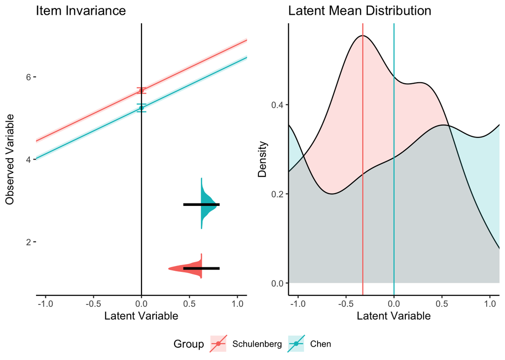

```
## -------
## Plot for RS3
```

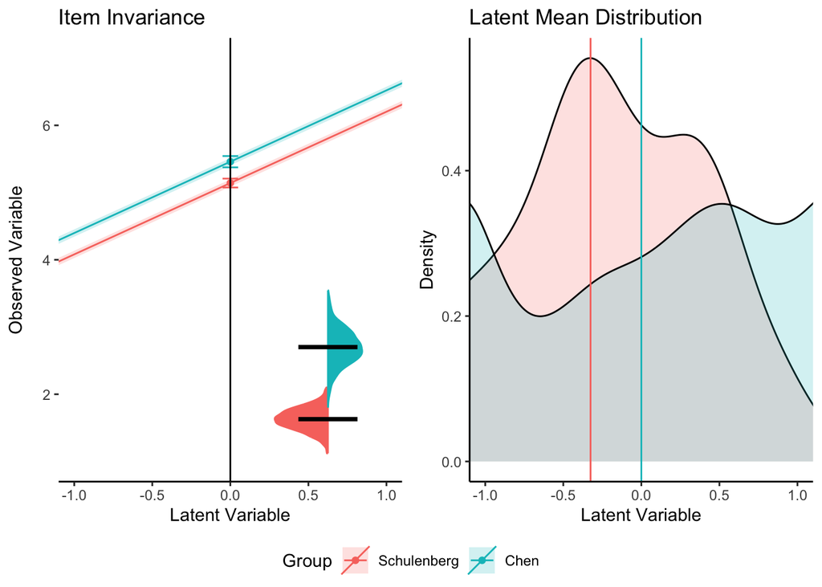

```r
for (i in c("RS2", "RS11",
            "RS4", "RS12",
            "RS14", "RS1",
            "RS10", "RS3")){
  cat(paste0("Plot for ", i, "\n"))
  print(plot_mi(
    # output from model_coef
    data_coef = partial.rs.1$model_coef,
    # which model do you want to plot
    model_step = "intercepts",
    # name of observed item
    item_name = i,
    # latent variable limits to graph
    x_limits = c(-1,1),
    # Y min and max in data
    y_limits = c(min(DF.combo[ , i]), max(DF.combo[ , i])),
    # what ci do you want
    conf.level = .95,
    # what model results do you want
    model_results = partial.rs.1$invariance_models$model.intercepts,
    # which latent variable do you want
    lv_name = "RS"
)$complete)

  ggsave(paste0("figures/rs14-chinese-", i, ".png"),
         dpi = 300,
         width = 8,
         units = "in")

  cat(paste0("-------\n"))

}
```

## Bootstrap Model

```r
boot.model.rs <-
  bootstrap_model(
    saved_configural = results.rs$model_configural,
    data = DF.combo,
    model = model.rs,
    group = "group",
    nboot = 1000,
    invariance_index = "cfi",
    invariance_rule = .01,
    group.equal = c("loadings", "intercepts")
)

boot.model.rs
```

```
##        model non_invariant random_non_invariant    h_nmi h_nmi_p
## 1 intercepts             1                    0 3.141593       1
```

In this case, we do not see loadings print out. That implies that all models in both real data and randomized data are invariant because the function only calculates information for non-invariance. We see that the intercepts are unlikely to ever replicate across Chinese and English samples. This result is not surprising given the large number of relaxed parameters required to achieve partial invariance.

## Bootstrap Partial Invariance

```r
boot.partial.rs <-
  bootstrap_partial(
    saved_model = results.rs$invariance_models$model.intercepts,
    data = DF.combo,
    model = model.rs,
    group = "group",
    nboot = 1000,
    invariance_index = "cfi",
    invariance_rule = .01,
    invariance_compare = fitmeasures(results.rs$invariance_models$model.loadings, "cfi"),
    partial_step = "intercepts",
    group.equal = c("loadings", "intercepts")
)
```

### Each Parameter on the Overall Model Invariance

```r
boot.partial.rs$boot_effects %>%
  select(term, non_invariant, random_non_invariant,
         h_nmi, h_nmi_p)
```

```
##        term non_invariant random_non_invariant    h_nmi  h_nmi_p
## 1    RS ~1              1                0.002 3.052120 0.971520
## 2   RS1 ~1              1                0.001 3.078337 0.979865
## 3  RS10 ~1              1                0.002 3.052120 0.971520
## 4  RS11 ~1              1                0.002 3.052120 0.971520
## 5  RS12 ~1              1                0.002 3.052120 0.971520
## 6  RS13 ~1              1                0.002 3.052120 0.971520
## 7  RS14 ~1              1                0.002 3.052120 0.971520
## 8   RS2 ~1              1                0.002 3.052120 0.971520
## 9   RS3 ~1              1                0.002 3.052120 0.971520
## 10  RS4 ~1              1                0.002 3.052120 0.971520
## 11  RS5 ~1              1                0.002 3.052120 0.971520
## 12  RS6 ~1              1                0.002 3.052120 0.971520
## 13  RS7 ~1              1                0.001 3.078337 0.979865
## 14  RS8 ~1              1                0.002 3.052120 0.971520
## 15  RS9 ~1              1                0.002 3.052120 0.971520
```

In this output, we see that all the bootstrapped runs of the real data are non-invariant, even when each parameter is relaxed individually. A few runs of the random data are *non*-invariant (meaning most are actually invariant when randomized). This indicates that no one parameter is likely the reason for non-invariance, as they all show large non-replication effects. If we use the `boot_summary`, we can see the effect size for each parameter when the two intercepts are compared to each other (as the chart above shows the overall model invariance effect).

### Each Parameter’s Standardized Difference Score

```r
boot.partial.rs$boot_summary %>%
  select(term, invariant, n_boot, d_boot)
```

```
##        term invariant n_boot     d_boot
## 1    RS ~1      FALSE   1000         NA
## 2   RS1 ~1      FALSE   1000  0.2913872
## 3  RS10 ~1      FALSE   1000  0.3596961
## 4  RS11 ~1      FALSE   1000 -0.6589317
## 5  RS12 ~1      FALSE   1000 -0.3010202
## 6  RS13 ~1      FALSE   1000 -0.4005088
## 7  RS14 ~1      FALSE   1000 -0.5665988
## 8   RS2 ~1      FALSE   1000 -0.5540349
## 9   RS3 ~1      FALSE   1000 -0.6218628
## 10  RS4 ~1      FALSE   1000 -0.6245830
## 11  RS5 ~1      FALSE   1000 -0.3334520
## 12  RS6 ~1      FALSE   1000 -0.5014247
## 13  RS7 ~1      FALSE   1000 -0.2381644
## 14  RS8 ~1      FALSE   1000 -0.6333750
## 15  RS9 ~1      FALSE   1000 -0.5986866
```

```r
boot.partial.rs$boot_summary %>%
  select(term, invariant, n_random, d_random)
```

```
##        term invariant n_random d_random
## 1    RS ~1      FALSE        2       NA
## 2   RS1 ~1      FALSE        1       NA
## 3  RS10 ~1      FALSE        2       NA
## 4  RS11 ~1      FALSE        2       NA
## 5  RS12 ~1      FALSE        2       NA
## 6  RS13 ~1      FALSE        2       NA
## 7  RS14 ~1      FALSE        2       NA
## 8   RS2 ~1      FALSE        2       NA
## 9   RS3 ~1      FALSE        2       NA
## 10  RS4 ~1      FALSE        2       NA
## 11  RS5 ~1      FALSE        2       NA
## 12  RS6 ~1      FALSE        2       NA
## 13  RS7 ~1      FALSE        1       NA
## 14  RS8 ~1      FALSE        2       NA
## 15  RS9 ~1      FALSE        2       NA
```

With the bootstrap summary, we see that no invariant intercept runs are found (not all columns shown to save space). Note that the `RS~1` does not calculate *d* because the *sd* is zero (thus, this would cause an error as *sd* is part of the denominator). The random runs also do not show a *d* score because the effect size is only calculated when at least 10% of the runs in `n_boot` or `n_random` are found. Since we only have a few in that column, no effect size is calculated. The differences in the intercepts for the real data (`boot` columns) appear to be medium to large, showing *d* scores from 0.3 to 0.6. Therefore, we might expect that the English and Chinese samples have different average endorsement levels of the RS14.

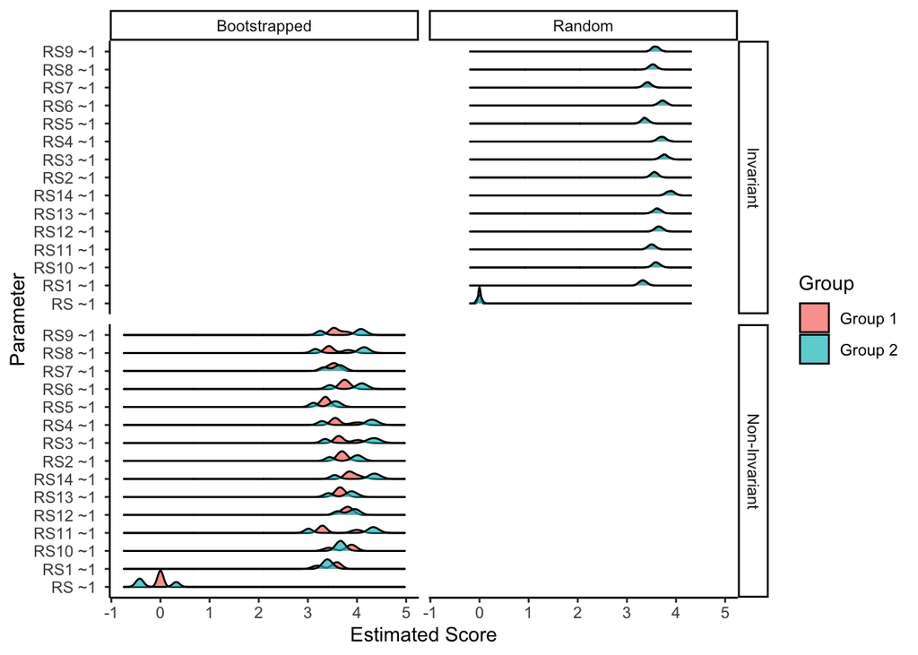

```r
boot.partial.rs$density_plot
```

```r
ggsave(paste0("figures/rs14-chinese-density_plot.png"),
       dpi = 300,
       width = 8,
       units = "in")
```

The examination of the density plot shows how group 1 (Schulenberg English) tends to show lower average scores than group 2 (Chen Chinese) for most but not all items.

We can view the mean difference or standardized mean difference by using:

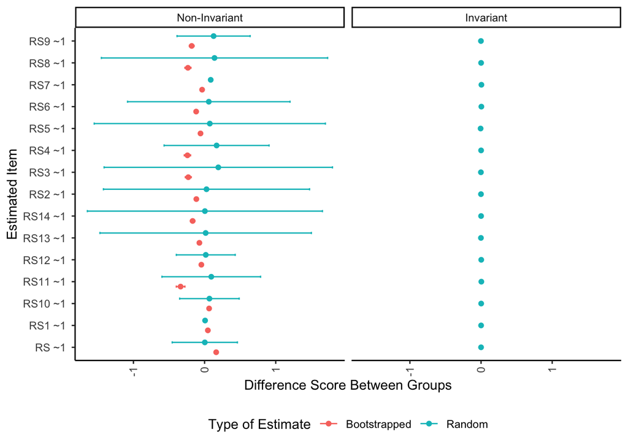

```r
boot.partial.rs$invariance_plot
```

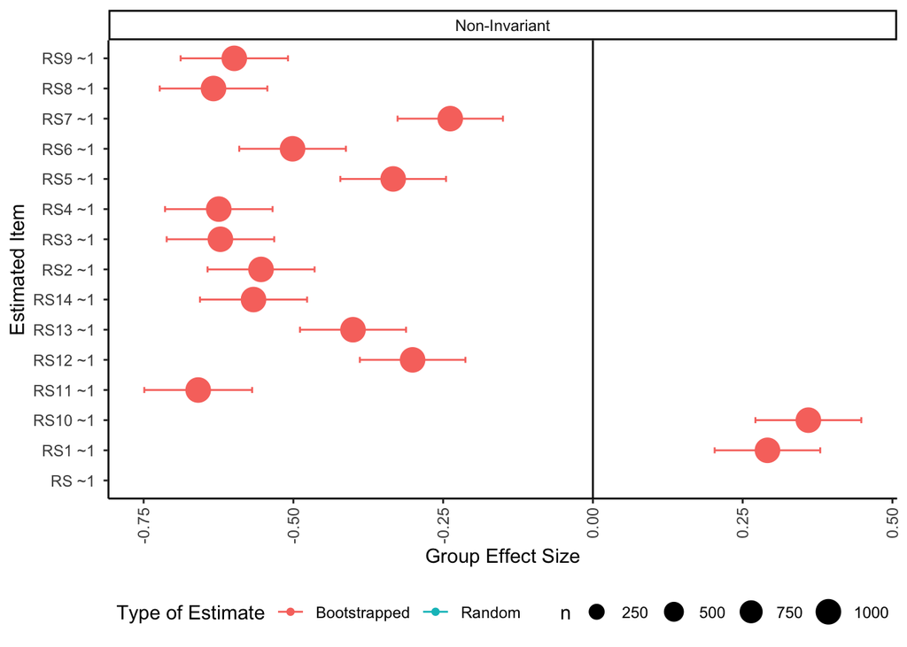

```r
ggsave(paste0("figures/rs14-chinese-invariance_plot.png"),
       dpi = 300,
       width = 8,
       units = "in")

boot.partial.rs$effect_invariance_plot
```

```r
ggsave(paste0("figures/rs14-chinese-effect_invariance_plot.png"),
       dpi = 300,
       width = 8,
       units = "in")
```